# R Notebook

# Aufgabe 15: Mehrfaktorielle Varianzanalyse (ohne Messwiederholung)

# Roadmap:

# 1) Hypothese

# 2) Voraussetzungen für die mehrfaktorielle Varianzanalyse (ohne Messwiederholung)

# 3) Normalverteilung

# 4) Grundlegende Konzepte

# 5) Boxplot

# 6) Deskriptive Statistiken

# 7) Profildiagramm

# 8) Levene -Test

# 9) Ergebnisse der mehrfaktorielle Varianzanalyse (ohne Messwiederholung)

# 10) Post-Hoc

# 11) Berechnung der Effektstärke

#### Effekt stärke

##12) Eine Aussage

## Beschreibung

Welchen Einfluss hat die Sportlichkeit(sportlich/unsportlich) und die Ernährung(Vegan, Vegetarisch, Rohkost, Mischkost) auf den Gesundheitindex gemessen durch den Hausartz? Findet Sie heraus, ob es einen Unterschied gibt?

## Daten

Variable1: Sportlichkeit (Faktor-1) Variable2: Ernaehrung (Faktor-2) Varibale3: Gesundheitsindex (AV)

```r
library(readxl)
mehranova <- read_excel("uebung15.xlsx")
mehranova
```

| ID | Sportlichkeit | Ernaehrung | Gesundheitsindex |
| --- | --- | --- | --- |
| 1 | unsportlich | vegan | 4 |
| 2 | unsportlich | vegan | 6 |
| 3 | unsportlich | vegan | 8 |
| 4 | unsportlich | vegan | 4 |
| 5 | unsportlich | vegan | 4 |
| 6 | unsportlich | vegan | 10 |
| 7 | unsportlich | vegan | 4 |
| 8 | unsportlich | vegan | 6 |
| 9 | unsportlich | vegan | 8 |
| 10 | unsportlich | vegan | 8 |

[output cut: 190 more lines]

```r
as.character(unique(mehranova$Sportlichkeit))
```

```
[1] "unsportlich" "sportlich"
```

```r
mehranova$Ernaehrung<-factor(mehranova$Ernaehrung, levels=c("vegan", "Rohkost", "vegetarisch", "Mischkost"))
```

# 1) Hypothese

Variable1: Sportlichkeit Variable2: Ernaehrung Varibale3: Gesundheitsindex

### Haupteffekt A

H0:Es gibt keinen Unterschied zwischen der Sportlichkeit und der Gesundheitsindex.

H1:Es gibt einen Unterschied zwischen der Sportlichkeit und der Gesundheitsindex.

### Haupteffekt B

H0:Es gibt einen Unterschied zwischen der Ernaehrung und der Gesundheitsindex.

H1:Es gibt einen Unterschied zwischen der Ernaehrung und der Gesundheitsindex.

### Interaktion AxB

H1: Es gibt einen Unterschied zwischen der Sportlichkeit, bzw. der Ernaehrung und der Gesundheitsindex.

H0: Es gibt keinen Unterschied zwischen der Sportlichkeit, bzw. der Ernaehrung und der Gesundheitsindex.

# 2) Voraussetzungen für die mehrfaktorielle Varianzanalyse (ohne Messwiederholung)

Die abhängige Variable (Gesundheitsindex) ist intervallskaliert -> ist gegeben, sogar absolutskaliert.

Die unabhängigen Variablen (Sportlichkeit und Ernaehrung) sind kategorial (nominalskaliert) -> sind sie.

Die durch die Faktoren gebildeten Gruppen sind unabhängig -> Entweder ist der Person sportlich / unsportlich , bzw. die Ernaehrung ist entweder Vegan, Vegetarisch, Rohkost oder Mischkost.

Die abhängige Variable (Gesundheitsindex) ist normalverteilt innerhalb jeder der Gruppen. Ab 25 Probanden pro Gruppe sind Verletzungen dieser Voraussetzung unproblematisch-> siehe Histogramm

Homogenität der Varianzen: Die Gruppen stammen aus Grundgesamtheiten mit annähernd identischen Varianzen der abhängigen Variablen -> siehe Levene-Test

# 3) Normalverteilung

### Ernaehrung

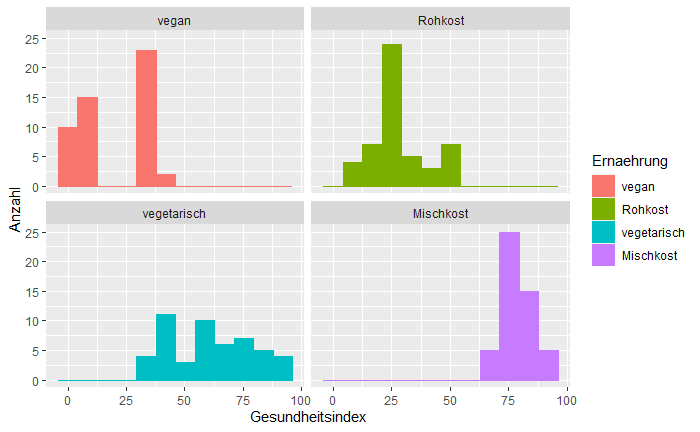

```r
library(dplyr)
library(ggplot2)
mehranova %>%
  group_by(Ernaehrung) %>%
  ggplot(aes(Gesundheitsindex, color=Ernaehrung)) +
  geom_histogram(aes(fill = Ernaehrung), bins = 12) +
  facet_wrap(~Ernaehrung) +
  theme_grey()+
  labs(x= "Gesundheitsindex",y = "Anzahl" )
```

Die Daten sind normalverteilt innerhalb der Gruppe Ernaehrung und Gesundheitsindex. Allerdings ist es nicht schön bei “vegan”.

### Sportlichkeit

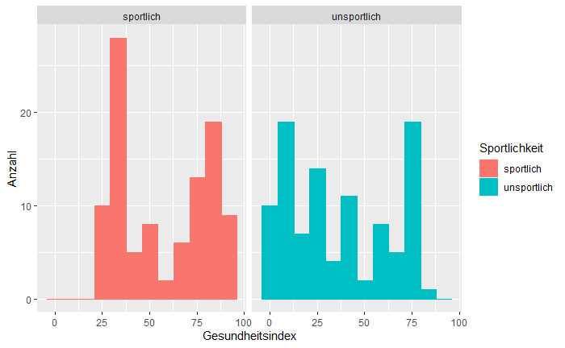

```r
mehranova %>%
  group_by(Sportlichkeit) %>%
  ggplot(aes(Gesundheitsindex, color=Sportlichkeit)) +
  geom_histogram(aes(fill = Sportlichkeit), bins = 12) +
  facet_wrap(~Sportlichkeit) +
  theme_grey()+
  labs(x= "Gesundheitsindex",y = "Anzahl" )
```

### Ernaehrung~Sportlichkeit

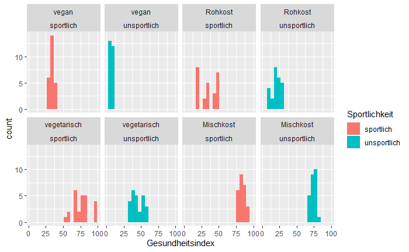

```r
ggplot(mehranova, aes(x=Gesundheitsindex, fill=Sportlichkeit))+
geom_histogram(bins = 20)+
theme_grey()+
facet_wrap(Ernaehrung~Sportlichkeit, ncol = 4)
```

### Alternativ (Ernaehrung~Sportlichkeit)

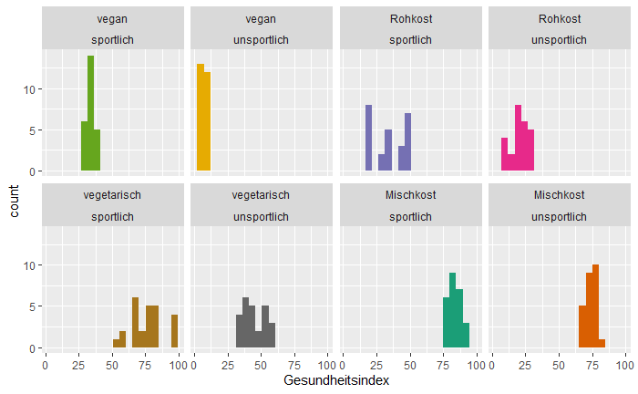

```r
ggplot()+
geom_histogram(data = mehranova, aes(Gesundheitsindex,
fill = paste(Ernaehrung, Sportlichkeit, sep = ", ")), bins = 20)+
scale_fill_brewer(palette = "Dark2", guide = FALSE)+

facet_wrap(Ernaehrung~Sportlichkeit, ncol = 4)
```

Ab 25 Teilnehmer pro Gruppe ist das Testverfahren robust. Jedoch gibt es Schwierigkeiten bei der Normalverteilung bei sportlich Rohkostesser.

# 4) Grundlegende Konzepte

Die mehrfaktorielle Varianzanalyse untersucht, ob sich die Mittelwerte mehrerer unabhängiger Gruppenunterscheiden, die durch mehrere kategoriale unabhängige Variable definiert werden. Diese UV werden bei der ANOVA als “Faktoren” bezeichnet. Die Ausprägungen der unabhängigen Variable werden “Faktorstufen” genannt (eng.“Treatments”)

Im Rahmen einer Varianzanalyse wird die Varianz zwischen den Gruppen mit der Varianz innerhalb der Gruppen verglichen.Die Fragestellung der mehrfaktoriellen Varianzanalyse könnte sein: “Unterscheiden sich die Mittelwerte einer abhängigen Variable zwischen mehreren Gruppen? Welche Faktorstufen unterscheiden sich? Gibt es Effekte?”

#### Haupteffekte und Interaktionseffekte

Der direkte Effekt eines Faktors auf die abhängige Variable wird als Haupteffekt bezeichnet. Im Beispiel sind dies der Haupteffekt der Ernaerung und der Haupteffekt der Sportlichkeit. Eine Interaktion zweier Faktoren dagegen bedeutet, dass die beiden Faktoren in komplexer Weise zusammenwirken. Dies ist nicht rein additiv zu verstehen. Liegt eine Interaktion vor, so ist die Wirkung des einen Faktors abhängig von der Ausprägung des anderen Faktors und umgekehrt. Im Beispiel gesprochen hiesse dies, dass der Effekt der Sportlichkeit auf die Gesundheitsindex sich je nach Ernaerung unterscheidet, und umgekehrt, dass der Effekt der Ernaerung je nach Sportlichkeit unterschiedlich ausfiele.

R schliesst automatisch alle möglichen Interaktionen in das Modell mit ein: Bei zwei Faktoren A und B ist dies die Interaktion A x B. Bei drei Faktoren A, B und C sind dies die Interaktion A x B, A x C, B x C sowie die Dreifachinteraktion A x B x C.

# 5) Boxplot

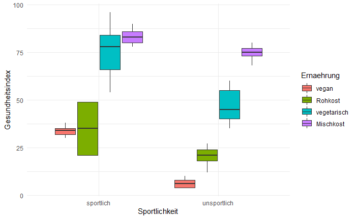

```r
ggplot(mehranova, aes(Sportlichkeit, Gesundheitsindex, fill=factor(Ernaehrung))) +
geom_boxplot() +
theme_minimal()+
labs(fill = "Ernaehrung", x="Sportlichkeit", y="Gesundheitsindex")
```

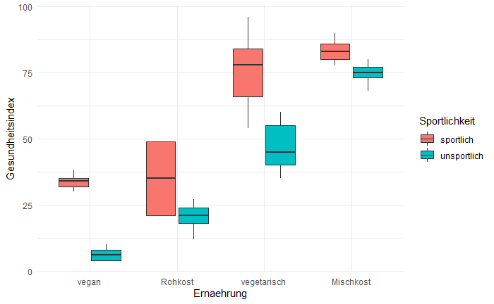

```r
ggplot(mehranova, aes(Ernaehrung, Gesundheitsindex, fill=factor(Sportlichkeit))) +
geom_boxplot() +
theme_minimal()+
labs(fill = "Sportlichkeit", x="Ernaehrung", y="Gesundheitsindex")
```

Es gibt keinen Ausreißer.

# 6) Deskriptive Statistiken

### Ernaehrung

```r
mehranova %>%
group_by(Ernaehrung) %>%
  summarize(Anzahl = n(), Mittelwert = mean(Gesundheitsindex), Median = median(Gesundheitsindex), Standardabweichung = sd(Gesundheitsindex)) %>%
  mutate_if(is.numeric, round, 2)
```

| Ernaehrung | Anzahl | Mittelwert | Median | Standardabweichung |
| --- | --- | --- | --- | --- |
| vegan | 50 | 20.10 | 20.0 | 13.96 |
| Rohkost | 50 | 27.56 | 24.0 | 11.44 |
| vegetarisch | 50 | 61.36 | 60.0 | 18.34 |
| Mischkost | 50 | 78.84 | 78.5 | 5.78 |

Veganesser hat 20.10 im Schnitt Gesundheitsindex (SD = 13.96, n=50). Mischkostesser hat 78.84 im Schnitt Gesundheitsindex (SD = 5.78, n=50). Es sieht so aus, dass Mischkostesser und Vegetarischesser gesunder als Veganesser und Rohkostesser sein könnten.

### Sportlichkeit

```r
mehranova %>%
group_by(Sportlichkeit) %>%
  summarize(Anzahl = n(), Mittelwert = mean(Gesundheitsindex), Median = median(Gesundheitsindex), Standardabweichung = sd(Gesundheitsindex)) %>%
  mutate_if(is.numeric, round, 2)
```

| Sportlichkeit | Anzahl | Mittelwert | Median | Standardabweichung |
| --- | --- | --- | --- | --- |
| sportlich | 100 | 56.98 | 51.5 | 24.56 |
| unsportlich | 100 | 36.95 | 31.0 | 26.67 |

Es zeichnet sich deutlich, dass der Sportlichkeitunterschied ist maximal. Sportlicher (M=56.98, SD=24.56, n=100) sind gesunder als Unsportlicher (M=36.95, SD=26.67, n=100).

### Ernaehrung~Sportlichkeit

```r
mehranova %>%
group_by(Sportlichkeit, Ernaehrung) %>%
  summarize(Anzahl = n(), Mittelwert = mean(Gesundheitsindex), Median = median(Gesundheitsindex), Standardabweichung = sd(Gesundheitsindex)) %>%
  mutate_if(is.numeric, round, 2)
```

```
`mutate_if()` ignored the following grouping variables:
Column `Sportlichkeit`
```

| Sportlichkeit | Ernaehrung | Anzahl | Mittelwert | Median | Standardabweichung |
| --- | --- | --- | --- | --- | --- |
| sportlich | vegan | 25 | 33.72 | 34 | 2.41 |
| sportlich | Rohkost | 25 | 34.72 | 35 | 11.52 |
| sportlich | vegetarisch | 25 | 76.32 | 78 | 12.19 |
| sportlich | Mischkost | 25 | 83.16 | 83 | 4.13 |
| unsportlich | vegan | 25 | 6.48 | 6 | 2.33 |
| unsportlich | Rohkost | 25 | 20.40 | 21 | 5.27 |
| unsportlich | vegetarisch | 25 | 46.40 | 45 | 8.48 |
| unsportlich | Mischkost | 25 | 74.52 | 75 | 3.50 |

Bei Mischkost sind sportliche Menschen (M = 83.16, SD = 4.13) gesunder als unsportliche Menschen (M = 74.52, SD = 3.50). Dies ist auch bei alle anderen ebenfalls der Fall. Bei sportliche Vegan (M = 33.72, SD = 2.41) ist der Gesundheitsindex deutlich stark gestiegen (unsportliche Vegan -> M = 6.48, SD = 2.33). Dies ist auch bei sportlichen vegetarischen Esser (M = 76.32, SD = 12.19) ebenfalls der Fall (unsportliche vegetarischen Esser -> M = 46.40, SD = 8.48).

### Alternative

```r
mittel <-tapply(mehranova$Gesundheitsindex, list(mehranova$Ernaehrung, mehranova$Sportlichkeit), mean, na.rm=TRUE)
mittel
```

```
            sportlich unsportlich
vegan           33.72        6.48
Rohkost         34.72       20.40
vegetarisch     76.32       46.40
Mischkost       83.16       74.52
```

```r
sd <-tapply(mehranova$Gesundheitsindex, list(mehranova$Ernaehrung, mehranova$Sportlichkeit), sd, na.rm=TRUE)
sd
```

```
            sportlich unsportlich
vegan        2.406934    2.329521
Rohkost     11.516365    5.267827
vegetarisch 12.188519    8.480369
Mischkost    4.129972    3.501428
```

```r
anzahlprogruppe <- tapply(mehranova$Gesundheitsindex, list(mehranova$Ernaehrung, mehranova$Sportlichkeit), function(x) sum(!is.na(x)))
anzahlprogruppe
```

```
            sportlich unsportlich
vegan              25          25
Rohkost            25          25
vegetarisch        25          25
Mischkost          25          25
```

# 7) Profildiagramm

```
`fun.y` is deprecated. Use `fun` instead.`fun.y` is deprecated. Use `fun` instead.
```

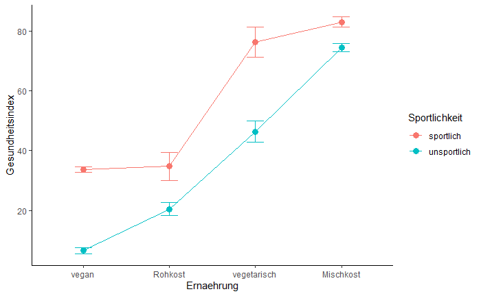

```r
ggplot(mehranova, aes(x=Ernaehrung, y=Gesundheitsindex, group=Sportlichkeit, fill=Sportlichkeit, color=Sportlichkeit))+
  stat_summary(fun.y = mean, geom="point", size=3)+
  stat_summary(fun.y = mean, geom="line")+
  stat_summary(fun.data = mean_cl_normal, geom="errorbar",width=.2, size=.25)+
  labs(x="Ernaehrung", y="Gesundheitsindex")+
  theme_classic()
```

Sport macht sinn. (gut) Jede Linie geht hoch. (gut)

# 8) Levene -Test (Homogenitaet)

Der Levene-Test prüft die Nullhypothese, dass die Varianzen der Gruppen sich nicht unterscheiden. Ist der Levene-Test nicht signifikant, so kann von homogenen Varianzen ausgegangen. Wäre der Levene-Test jedoch signifikant, so wäre eine der Grundvoraussetzungen der Varianzanalyse verletzt. Gegen leichte Verletzungen gilt die Varianzanalyse als robust; vor allem bei genügend grossen und etwa gleich grossen Gruppen sind Verletzungen nicht problematisch. Bei ungleich grossen Gruppen führt eine starke Verletzung der Varianzhomogenität zu einer Verzerrung des F-Tests. Alternativ können dann auf den Brown-Forsythe-Test oder den Welch-Test zurückgegriffen werden. Dabei handelt es sich um adjustierte F-Tests.

```r
library(car)
```

```r
leveneTest(Gesundheitsindex ~ Ernaehrung*Sportlichkeit, data = mehranova, center = "mean")
```

```
Levene's Test for Homogeneity of Variance (center = "mean")
       Df F value    Pr(>F)
group   7  20.563 < 2.2e-16 ***
      192
---
Signif. codes:  0 ‘***’ 0.001 ‘**’ 0.01 ‘*’ 0.05 ‘.’ 0.1 ‘ ’ 1
```

Im vorliegenden Beispiel ist der Levene-Test signifikant (F(7,192) = 20.563, p < .000 ), so dass von Varianzheterogenität ausgegangen werden kann. Da die Varianzen leider nicht gleich sind, ist es zu empfehlen eine Korrektur mithilfe des Welch-Tests durchzuführen.

### Entscheiungsregeln

Mit Welch-Korrektur: p < 0.05 => Ergebnis Signifikant –> Varianzen heterogen

Ohne Welch-Korrektur: p > 0.05 => Ergebnis nicht Signifikant –> Varianzen homogen –> H0 mit Annahme Var1=Var2=… -> Var_n wird angenommen

# 9) Ergebnisse der mehrfaktorielle Varianzanalyse (ohne Messwiederholung)

### Keine Welch-Korrektur

```r
mehrAnova1 <- lm(Gesundheitsindex ~ Sportlichkeit*Ernaehrung, data = mehranova)
myAnova <- Anova(mehrAnova1 , type = 3)
myAnova
```

```
Anova Table (Type III tests)

Response: Gesundheitsindex
                         Sum Sq  Df F value    Pr(>F)
(Intercept)               28426   1 539.661 < 2.2e-16 ***
Sportlichkeit              9275   1 176.088 < 2.2e-16 ***
Ernaehrung                52399   3 331.595 < 2.2e-16 ***
Sportlichkeit:Ernaehrung   3902   3  24.691  1.48e-13 ***
Residuals                 10113 192
---
Signif. codes:  0 ‘***’ 0.001 ‘**’ 0.01 ‘*’ 0.05 ‘.’ 0.1 ‘ ’ 1
```

### mit Welch-Korrektur

```r
Sportlichkeitwelch <- oneway.test(Gesundheitsindex~Sportlichkeit, data = mehranova, var.equal = F)
Sportlichkeitwelch
```

```
    One-way analysis of means (not assuming equal variances)

data:  Gesundheitsindex and Sportlichkeit
F = 30.532, num df = 1.00, denom df = 196.67, p-value = 1.033e-07
```

Für den Faktor Sportlichkeit wird ein Haupteffekt ersichtlich. Die Gesundheitsindex scheint demnach abhängig vom Sportlichkeit zu sein (F(1, 196.67) = 30.532, p = .000).

```r
Ernaehrungwelch <- oneway.test(Gesundheitsindex~Ernaehrung, data = mehranova, var.equal = F)
Ernaehrungwelch
```

```
    One-way analysis of means (not assuming equal variances)

data:  Gesundheitsindex and Ernaehrung
F = 436.71, num df = 3.00, denom df = 99.02, p-value < 2.2e-16
```

Es gibt einen Haupteffekt der Ernaehrung auf die Gesundheitsindex (F(3, 99.02) = 436.71, p < .000). Die Gesundheitsindex scheint demnach abhängig von der Ernaehrung zu sein.

```r
AXBwelch <- oneway.test(Gesundheitsindex~Ernaehrung*Sportlichkeit, data = mehranova, var.equal = F)
AXBwelch
```

```
    One-way analysis of means (not assuming equal variances)

data:  Gesundheitsindex and Ernaehrung * Sportlichkeit
F = 1477.3, num df = 7.000, denom df = 80.776, p-value < 2.2e-16
```

# 10) Post-Hoc

Ist ein Haupteffekt oder eine Interaktion signifikant, so ist zwar bestätigt, dass ein Effekt vorliegt, doch ist nach wie vor unklar, welche Faktorstufen sich unterscheiden, sobald ein Faktor mehr als zwei Ausprägungen aufweist. (Bei zwei Ausprägungen unterscheiden sich eben diese zwei Ausprägungen voneinander, sonst wäre der F-Test nicht signifikant.) Im vorliegenden Beispiel liegen ein Effekt der Ernaehrung, sowie ein Interaktionseffekt vor. Post-hoc-Tests können einfach eingesetzt werden, um zu prüfen, welche Levels der Ernaehrung sich unterscheiden. Für die Interaktion ist dies in SPSS nicht implementiert.

Wie bereits erwähnt wurde, beinhaltet der Faktor Ernaehrung vier Stufen. Aus dem signifikanten Haupteffekt lässt sich nicht ableiten, welche der Faktorstufen einen signifikant unterschiedlichen Einfluss auf die abhängige Variable (Gesundheitsindex) haben. Zu diesem Zweck werden Tukey-korrigierte Mehrfachvergleiche berechnet.

Bei der Berechnung von Post-hoc-Tests wird im Prinzip für jede Kombination von zwei Mittelwerten ein t-Test durchgeführt. Im aktuellen Beispiel die Ernaehrung mit vier Gruppen, bzw. zwei Gruppen sind dies 28 Tests. Multiple Tests sind jedoch problematisch, da der Alpha-Fehler (die fälschliche Ablehnung der Nullhypothese) mit der Anzahl der Vergleiche steigt. Wird nur ein t-Test mit einem Signifikanzlevel von .05 durchgeführt, so beträgt die Wahrscheinlichkeit des Nicht-Eintreffens des Alpha-Fehlers 95%. Werden jedoch 28 solcher Paarvergleiche vorgenommen, so beträgt die Nicht-Eintreffens-Wahrscheinlichkeit des Alpha-Fehlers (.95)^28 = 0.2378. Um die Wahrscheinlichkeit des Eintreffens des Alpha-Fehlers zu bestimmen, wird 1 - 0.2378 = 0.7621 gerechnet. Die Wahrscheinlichkeit des Eintreffens des Alpha-Fehlers liegt somit bei 76.21%. Diese Fehlerwahrscheinlichkeit wird als “Familywise Error Rate” bezeichnet.

Um dieses Problem zu beheben, kann zum Beispiel die Tukey-Korrektur angewendet werden. Hierbei wird α durch die Anzahl der Paarvergleiche dividiert. Im hier aufgeführten Fall ist dies .05/28 = .00178. Bei diesem Konzept handelt es sich um eine allgemeine Information.

Die Tukey berücksichtigt die Korrektur, daher kann weiter gegen 0.05 getestet werden.

```r
PostHoc <- aov(Gesundheitsindex ~ Sportlichkeit*Ernaehrung, data=mehranova)
#Alternativ auch der Name des Zwischenspeichers "mehr" - PostHoc <- aov(mehr)
TukeyHSD(PostHoc)
```

```
  Tukey multiple comparisons of means
    95% family-wise confidence level

Fit: aov(formula = Gesundheitsindex ~ Sportlichkeit * Ernaehrung, data = mehranova)

$Sportlichkeit
                        diff       lwr       upr p adj
unsportlich-sportlich -20.03 -22.05445 -18.00555     0

$Ernaehrung
                       diff     lwr     upr p adj
Rohkost-vegan          7.46  3.6981 11.2219 4e-06
vegetarisch-vegan     41.26 37.4981 45.0219 0e+00
Mischkost-vegan       58.74 54.9781 62.5019 0e+00
vegetarisch-Rohkost   33.80 30.0381 37.5619 0e+00
Mischkost-Rohkost     51.28 47.5181 55.0419 0e+00
Mischkost-vegetarisch 17.48 13.7181 21.2419 0e+00

$`Sportlichkeit:Ernaehrung`
                                                diff         lwr        upr     p adj
unsportlich:vegan-sportlich:vegan             -27.24 -33.5310795 -20.948921 0.0000000
sportlich:Rohkost-sportlich:vegan               1.00  -5.2910795   7.291079 0.9997066
unsportlich:Rohkost-sportlich:vegan           -13.32 -19.6110795  -7.028921 0.0000000
sportlich:vegetarisch-sportlich:vegan          42.60  36.3089205  48.891079 0.0000000
unsportlich:vegetarisch-sportlich:vegan        12.68   6.3889205  18.971079 0.0000001
sportlich:Mischkost-sportlich:vegan            49.44  43.1489205  55.731079 0.0000000
unsportlich:Mischkost-sportlich:vegan          40.80  34.5089205  47.091079 0.0000000
sportlich:Rohkost-unsportlich:vegan            28.24  21.9489205  34.531079 0.0000000
unsportlich:Rohkost-unsportlich:vegan          13.92   7.6289205  20.211079 0.0000000
sportlich:vegetarisch-unsportlich:vegan        69.84  63.5489205  76.131079 0.0000000
unsportlich:vegetarisch-unsportlich:vegan      39.92  33.6289205  46.211079 0.0000000
sportlich:Mischkost-unsportlich:vegan          76.68  70.3889205  82.971079 0.0000000
unsportlich:Mischkost-unsportlich:vegan        68.04  61.7489205  74.331079 0.0000000
unsportlich:Rohkost-sportlich:Rohkost         -14.32 -20.6110795  -8.028921 0.0000000
sportlich:vegetarisch-sportlich:Rohkost        41.60  35.3089205  47.891079 0.0000000
unsportlich:vegetarisch-sportlich:Rohkost      11.68   5.3889205  17.971079 0.0000013
sportlich:Mischkost-sportlich:Rohkost          48.44  42.1489205  54.731079 0.0000000
unsportlich:Mischkost-sportlich:Rohkost        39.80  33.5089205  46.091079 0.0000000
sportlich:vegetarisch-unsportlich:Rohkost      55.92  49.6289205  62.211079 0.0000000
unsportlich:vegetarisch-unsportlich:Rohkost    26.00  19.7089205  32.291079 0.0000000
sportlich:Mischkost-unsportlich:Rohkost        62.76  56.4689205  69.051079 0.0000000
unsportlich:Mischkost-unsportlich:Rohkost      54.12  47.8289205  60.411079 0.0000000
unsportlich:vegetarisch-sportlich:vegetarisch -29.92 -36.2110795 -23.628921 0.0000000
sportlich:Mischkost-sportlich:vegetarisch       6.84   0.5489205  13.131079 0.0226215
unsportlich:Mischkost-sportlich:vegetarisch    -1.80  -8.0910795   4.491079 0.9877939
sportlich:Mischkost-unsportlich:vegetarisch    36.76  30.4689205  43.051079 0.0000000
unsportlich:Mischkost-unsportlich:vegetarisch  28.12  21.8289205  34.411079 0.0000000
unsportlich:Mischkost-sportlich:Mischkost      -8.64 -14.9310795  -2.348921 0.0010119
```

4 Stück denken wir: Alle Ernährungen und Ihre Sportlichkeiten

Wie vermutet, die Ernaeherung-GesundheitsindexKombinationen unterscheiden sich signifikant. Dies ist auch bei der Sportlichkeit-GesundheitsindexKombinationen ebenfalls der Fall.

Für das vorliegende Beispiel wird ersichtlich, dass sich die Ernaeherung und die Sportlichkeit bezüglich der Gesundheitsindex signifikant unterscheiden (p < .05). Jedoch kann kein Unterschied:

- zwischen der Rohkost und Vegan mit einem Sportlicher (p = .999),
- zwischen dem Mischkost-Unsportlicher und dem vegetarisch-Sporlicher (p = .987)

# 11) Berechnung der Effektstärke

#### Eta-Quadrat

Das partielle Eta-Quadrat (partielles η2) ist in Abbildung ausgegeben. Es ist ein Mass für die Effektgrösse: Es setzt die Variation, die durch einen Faktor erklärt wird, in Bezug mit jener Variation, die nicht durch andere Faktoren im Modell erklärt wird. Das heisst, es wird ausschliesslich jene Variation betrachtet, welche nicht durch die anderen Faktoren im Modell erklärt wird. Das partielle Eta-Quadrat zeigt, welchen Anteil davon ein Faktor erklärt:

```r
library(sjstats)

eta <- eta_sq(mehrAnova1, partial = TRUE)
eta
```

```
                      term partial.etasq
1            Sportlichkeit         0.665
2               Ernaehrung         0.920
3 Sportlichkeit:Ernaehrung         0.278
```

Für die Sportlichkeit beträgt das partielle Eta-Quadrat .665. Das heisst, die Sportlichkeit erklärt 66.5% derjenigen Fehlervariation, die das Modell hätte, wäre die Sportlichkeit nicht im Modell. Für die Ernaeherung beträgt das partielle Eta-Quadrat .920. Das heisst, die Ernaeherung erklärt 92% derjenigen Fehlervariation, die das Modell hätte, wäre die Ernaeherung nicht im Modell. Das partielle Eta-Quadrat der Interaktion beträgt .278 und erklärt daher 27.8% der ohne die Interaktion ungeklärten Variation.

#### Effekt stärke

$$f=\sqrt\frac{\eta^{2}}{1-\eta^{2}}=\sqrt\frac{eta^{2}}{1-eta^{2}}$$

Effektstärke fürs Sportlichkeit:

```r
effsport <- sqrt(eta$partial.etasq[1]/(1-eta$partial.etasq[1]))

sprintf("Effektstärke fürs Sportlichkeit: f= %.3f", effsport)
```

```
[1] "Effektstärke fürs Sportlichkeit: f= 1.408"
```

Effektstärke fürs Ernaeherung:

```r
effern <- sqrt(eta$partial.etasq[2]/(1-eta$partial.etasq[2]))

sprintf("Effektstärke fürs Ernaeherung: f= %.3f",effern)
```

```
[1] "Effektstärke fürs Ernaeherung: f= 3.388"
```

Effektstärke für die Interaktion:

```r
effAxB <- sqrt(eta$partial.etasq[3]/(1-eta$partial.etasq[3]))

sprintf("Effektstärke für die Interaktion: f= %.3f",effAxB)
```

```
[1] "Effektstärke für die Interaktion: f= 0.621"
```

Um zu beurteilen, wie gross dieser Effekt ist, kann man sich an der Einteilung von Cohen (1988) orientieren:

f = .10 entspricht einem schwachen Effekt f = .25 entspricht einem mittleren Effekt f = .40 entspricht einem starken Effekt

Damit entsprechen die Effektstärken von 1.408, 3.388 und 0.621 einem starken Effekt.

# 12) Eine Aussage

Es zeigt sich, dass es einen Unterschied zwichen der Sportlichkeit und der Gesundheitsindex allein gibt ((F(1, 196.67) = 30.532, p = .000)). H0 für den Haupteffekt A wird verworfen und H1 angenommen.

Je nach Ernaehrung gibt es einen Unterschied zwischen den Gesundheitsindexen (F(3, 99.02) = 436.71, p < .000). H0 für den Haupteffekt B wird verworfen und H1 angenommen.

Die Effektstärken sind für den Haupteffekt der Ernaehrung (f = 3.388), der Sportlichkeit (f = 1.408) und der Interaktion (f = 0.621) nach Cohen (1988) ein starker Effekt.

# Aussage-Juliana:

#### Ergebnis der Hypothesen-Prüfung

Es zeigt sich, dass es einen Einfluss der Sportlichkeit auf den Gesundheitsindex gibt (F(1.00, 196.67)=30.532, p =.000).H0 für den Haupteffekt A wird verworfen. Je nach Ernährungsart gibt es einen Einfluss auf den Gesundheitsindex (F(3.00, 99.02)= 436.71, p = .000). H0 für den Haupteffekt B wird verworfen.

Tukey-PostHoc-Tests zeigt, dass sich alle Gruppen für Ernaehrung signifikant unterscheiden: Mischkost (M=78.84 SD=5.78, N=50), Rohkost(M=27.56 SD=11.4, N=50), vegan (M=20.10 SD=13.96 , N=50) und vegetarisch (M=61.36 SD=18.34, N=50). Auch alle Gruppen für Sportlichekit: sportlich (M=56.98 SD=24.56, N=100) und unsportlich (M=36.95 SD=26.67,N=100).

Zudem zeigt sich eine signifikante Interaktion von Sportlichkeit und Ernährung auf den Gesundheitsindex. Dies weist darauf hin, dass sich die Sportlichkeit je nach Ernährung unterschiedlich auswirkt und umgekehrt.

Für das vorliegende Beispiel wird ersichtlich, dass sich sportliches Verhalten mit Rohkosternährung und sportliches Verhalten mit veganer Ernährung bezüglich des Gesundheitsindexmittelwertes nicht signifikant unterscheiden (p = 0.9).

Außerdem kann kein Unterschied für sportliches Verhalten mit vegetarischer Ernährung und unsportlichen Verhalten mit Mischkost festgestellt werden (p = 0.9).

#### Ergebnis für die Effektstärken

Die Effektstärken sind sowohl

nach Cohen (1988) ein starker Effekt.